# LAD calibration

# First results

```
##   id_mod species_specific dbh_effect compet_effect
## 1      1             TRUE       TRUE          TRUE
```

We ran 50,000 samplings for each of the 3 chains. We analyse the output by keeping the last 6,500 samplings of each chain.

The total computation time was about:

```
## Time difference of 18.36656 hours
```

## Species effect

### Trace

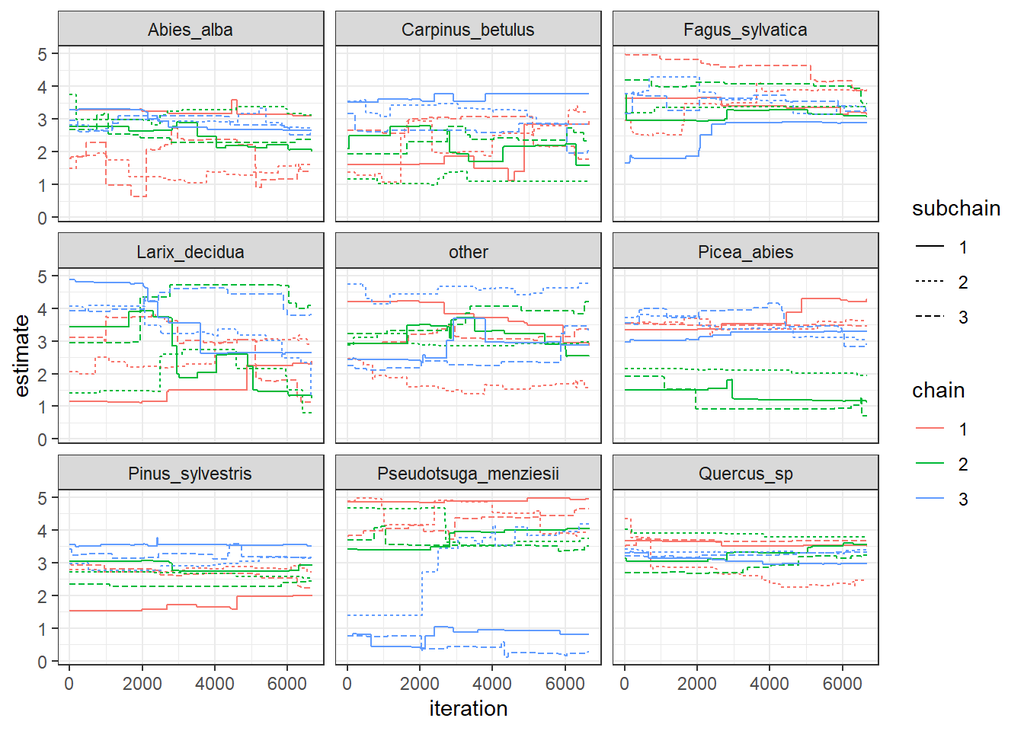

### Density

```
##                 species     lower   median    upper
## 1      Carpinus_betulus 1.0362458 2.578466 3.769011
## 2            Abies_alba 1.0554481 2.739253 3.384926
## 3      Pinus_sylvestris 1.5354992 2.766312 3.552506
## 4         Larix_decidua 1.1372229 2.976119 4.785523
## 5                 other 1.5195790 3.066878 4.656755
## 6            Quercus_sp 2.3422123 3.310528 3.900754
## 7           Picea_abies 0.9239914 3.331509 4.203458
## 8       Fagus_sylvatica 1.7919501 3.468471 4.823969
## 9 Pseudotsuga_menziesii 0.2386393 3.697736 4.973740
```

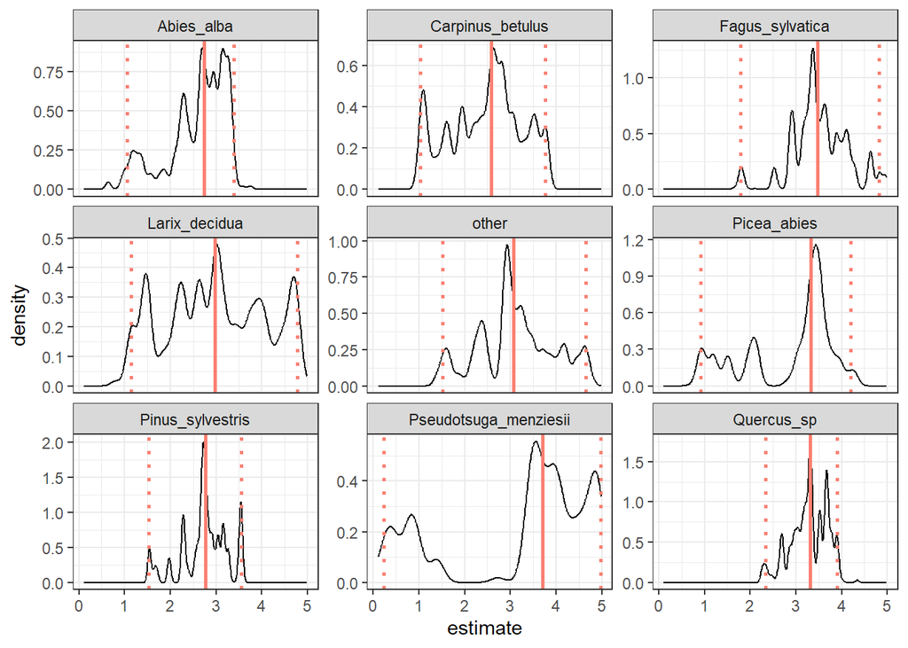

## DBH effect

### Trace

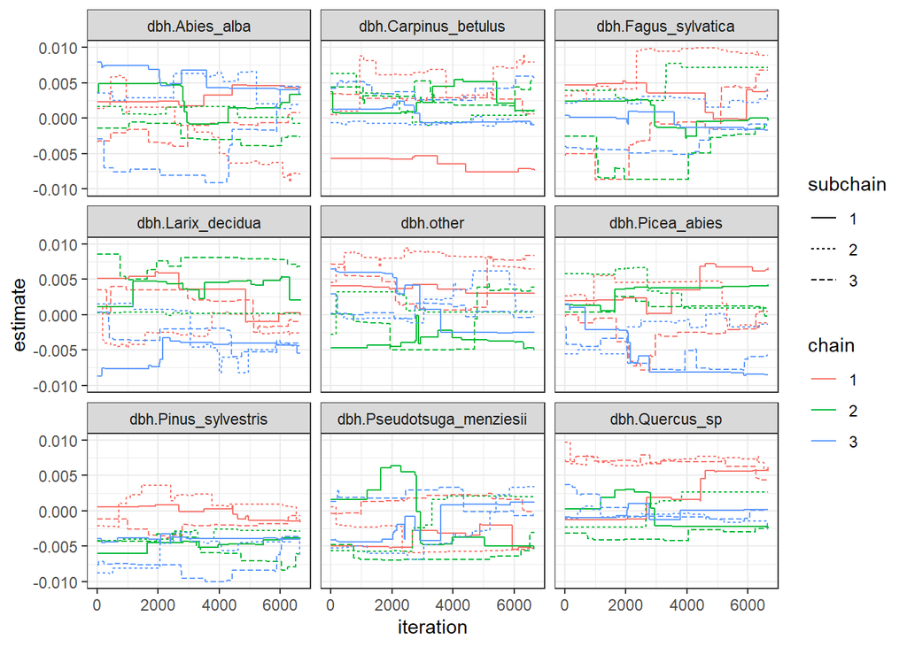

### Density

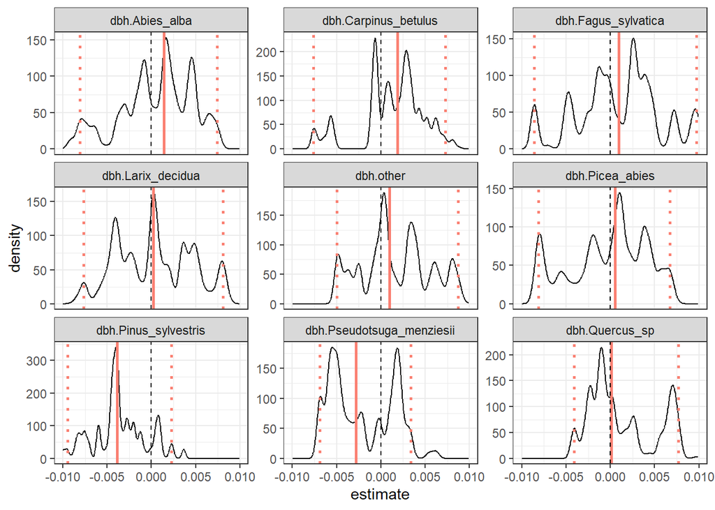

## Competition effect

The competition effect is the BAHT (basal area of higher trees, in $m^2.ha{-1}$), i.e. similar to BAL but considering the higher trees, not the larger ones).

### Trace

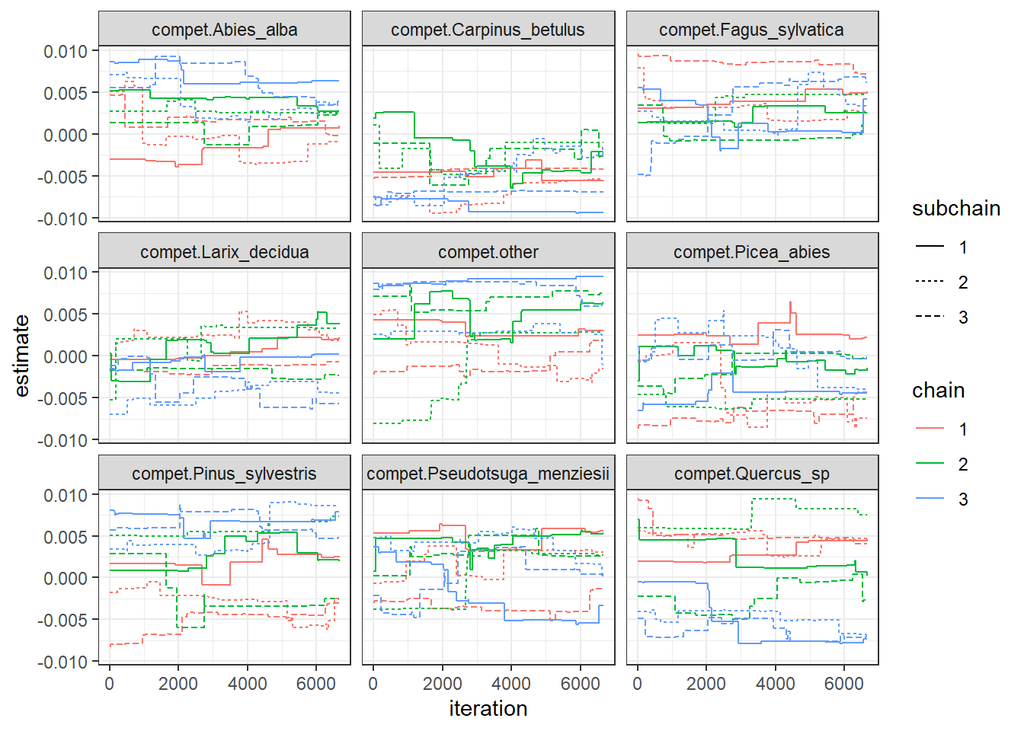

### Density

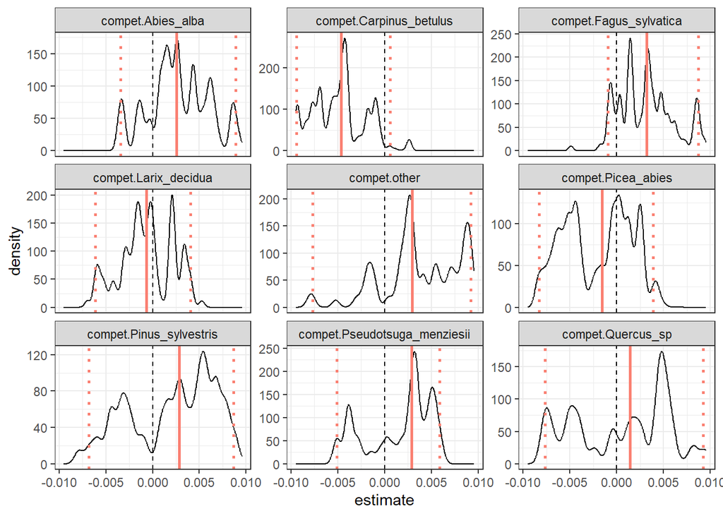

## Site and origin effects

### Trace - origins

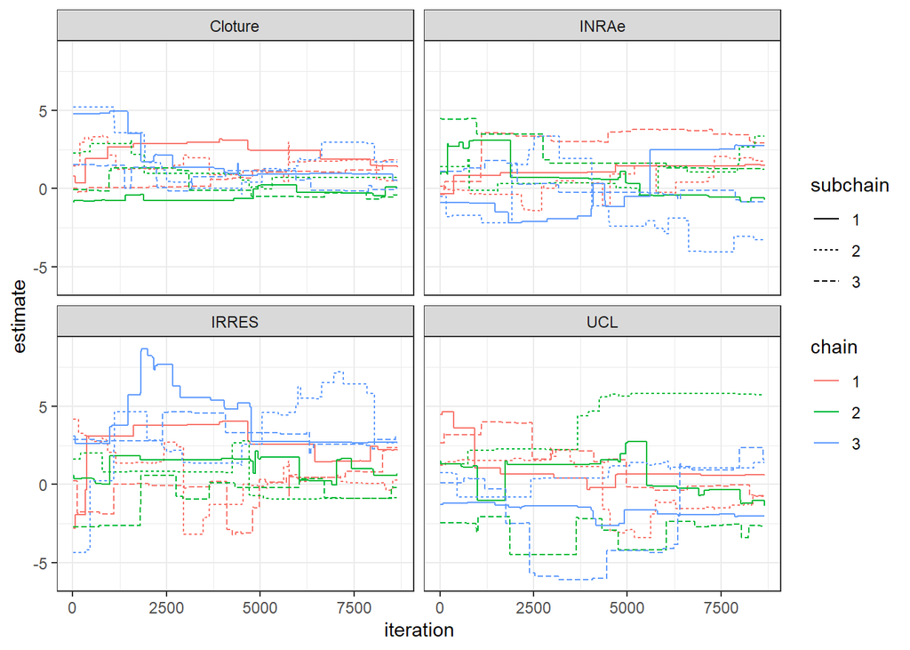

### Density - origins

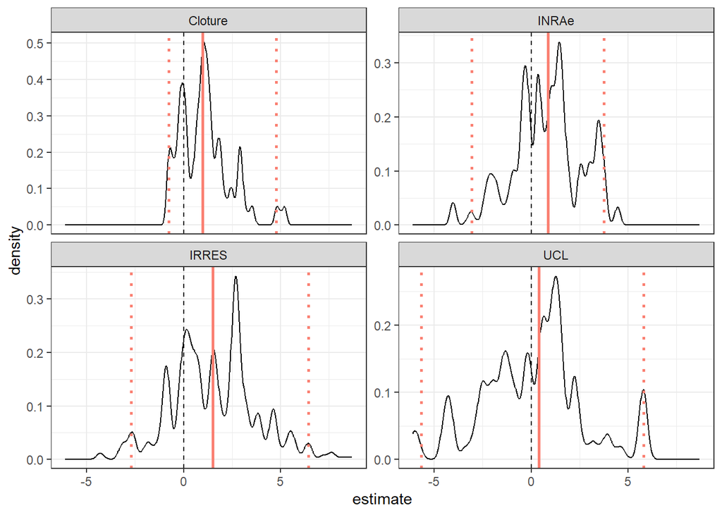

### Trace - sites

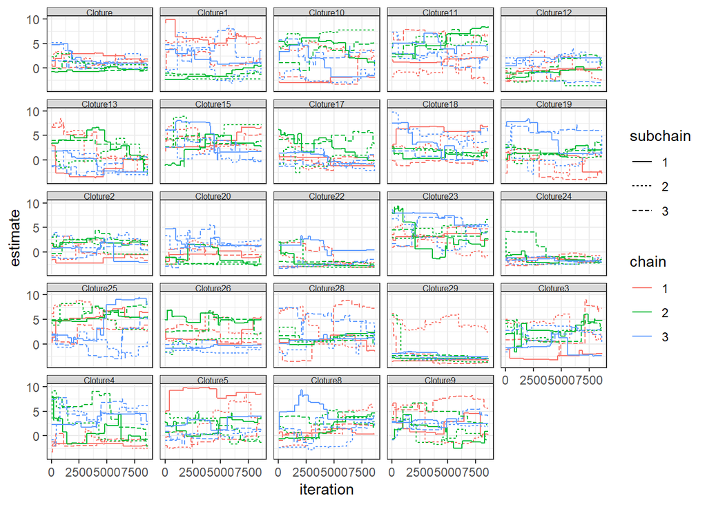

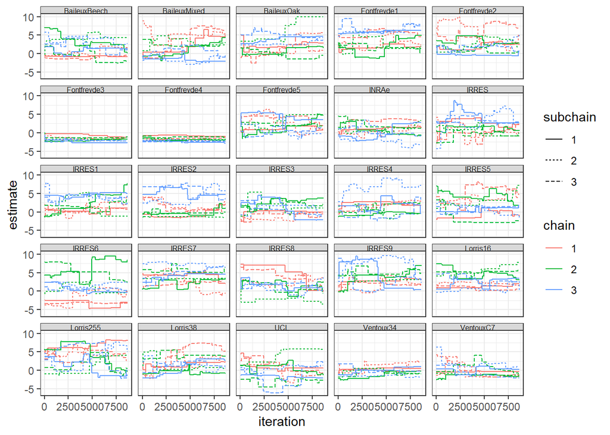

### Density - sites

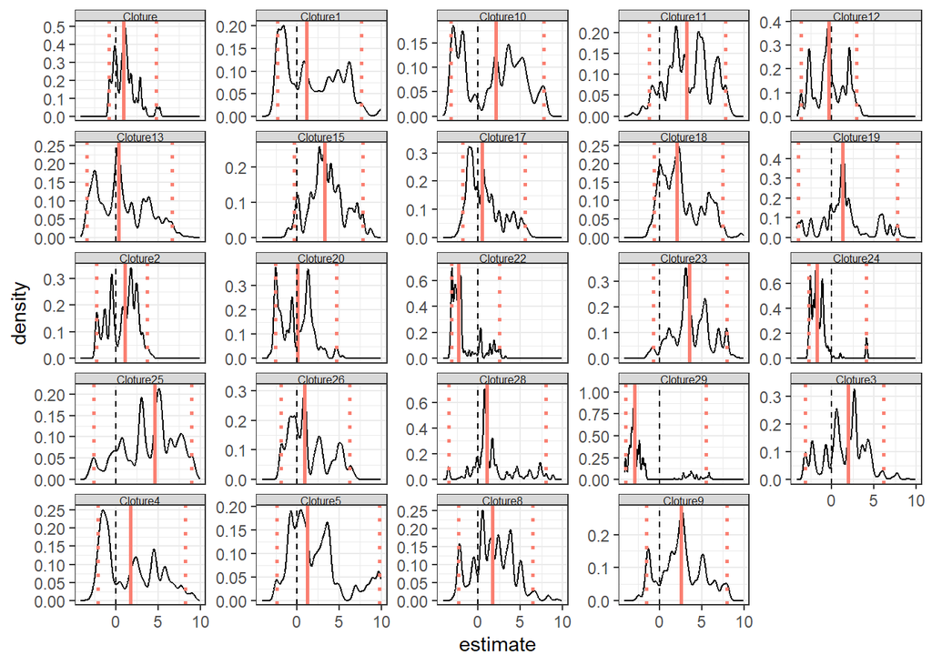

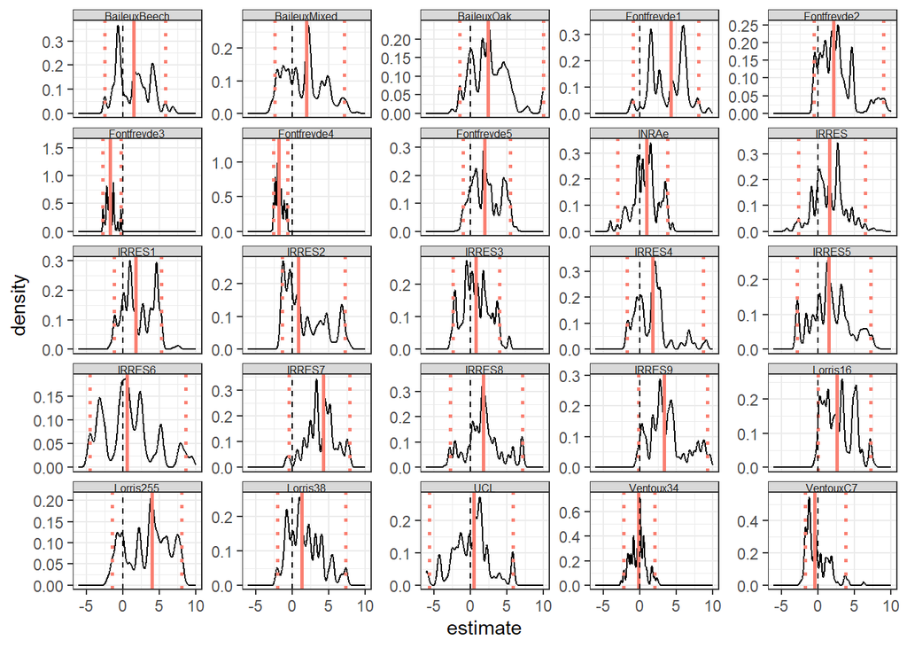

# Limits

**There is still problem of convergence,** we need to explore why. Intercept and slope can compensate for each other (e.g., high intercept with negative slope vs low intercept with positive slope), the model may not be fully identifiable with the current data: Standardize predictors (like dbh and BALh) to reduce correlation with the intercept, consider covariance between slopes and intercept or constrain parameters using more informative priors (e.g. high or low LAD ?)

**We could imagine** **another index of competition such as dbh/dg**, which represents more a relative index of competition (i.e. a status within the stand), rather than an absolute index such as BALh. Moreover, the effects are linear, but we could imagine transformations to model for example a plateau effect for competition ?

**The model may be highly sensitive to the trees we consider in the likelihood.** For the computation of the likelihood, we could consider only the trees in a given radius (e.g. 15m) around each sensor ? Indeed, it could lead to non convergence if we consider trees that have no influence on the sensor PACL, as no matter the LAD, PACL and thus residuals won’t change. Maybe consider a radius that depend on the tree dbh ? Because large trees will have a larger spatial influence on light on the ground than smaller trees. It may necessitate a preliminary study to analyse the shading area of the trees.

# Perspectives

Once we are satisfied with the modelling approach, we will study the ecological mechanisms that could underlie the differences between species. Do species with different shade tolerance have different leaf area densities? Do they react differently to competition? **Ecological assumptions still have to be made.**